# TSO concentration in exp. 8’s source plate

RT optimisation with the Labcyte Echo 525. Source plate QC.

Concentrations of the actual TSO solutions in source plates, measured with a NanoDrop 8000, that has a dynamic range of 2.5–3,700 ng/μL for dsDNA according to the manufacturer’s website.

# Load R packages

```r
library("magrittr")
library("ggplot2")
```

# Load data

## Source plate

Original file name `180528_kato.xlsx`. This file is for the source plate used in experiment 8, which uses transfer design 7.

```r
source <- gdata::read.xls( "Labcyte-Exp8.quantification.xlsx"
                         , nrow = 210, sheet = 1, stringsAsFactors = FALSE)

source$Plate.ID <- "exp8"
source$col      <- source$Well. %>% sub(pat = ".", rep = "")
source$row      <- source$Well. %>% substr(1,1)
```

TSOs were transferred from the source plate to a dillution plate, in new coordinates documented in sheet 2. The command below reconstructs the well names.

```r
source$orig_well  <- apply( expand.grid( c("01", "03", "05", "07", "02", "04", "06")
                                       , unlist( lapply( LETTERS[1:10]
                                                       , rep
                                                       , 3)))
                          , MARGIN = 1
                          , function(x) paste0(x[2], x[1]))
```

## Average replicates

```r
conc <- data.frame( Well  = source$orig_well
                  , plate = source$Plate.ID
                  , A260  = source$A260.
                  , A280  = source$A280.
                  , stringsAsFactors = FALSE)

conc.sd <- aggregate( conc[,c("A260", "A280")]
                    , list(Well = conc$Well, plate = conc$plate)
                    , sd)

conc <-    aggregate( conc[,c("A260", "A280")]
                    , list(Well = conc$Well, plate = conc$plate)
                    , mean)

conc$CV <- conc.sd$A260 / conc$A260

summary(conc)
```

```
##      Well              plate                A260               A280               CV
##  Length:70          Length:70          Min.   : 0.02633   Min.   :0.01767   Min.   :0.0007188
##  Class :character   Class :character   1st Qu.: 6.07700   1st Qu.:3.50667   1st Qu.:0.0057552
##  Mode  :character   Mode  :character   Median : 6.47817   Median :3.80050   Median :0.0137396
##                                        Mean   : 6.88756   Mean   :3.99223   Mean   :0.0227364
##                                        3rd Qu.: 7.52992   3rd Qu.:4.35267   3rd Qu.:0.0259328
##                                        Max.   :12.83600   Max.   :7.50067   Max.   :0.1112838
```

## Barcode IDs

See design 7 if you would like to double-check.

```r
#               1   2   3   4   5   6   7
conc$ID  <- c(  1, 13, 25, 37, 49, 61, 73  # A
             ,  2, 14, 39, 38, 50, 62, 74  # B
             ,  4, 16, 28, 40, 64, 76, 88  # C
             ,  5, 17, 29, 41, 65, 77, 89  # D
             , 51, 18, 30, 42, 66, 78, 90  # E
             ,  7, 19, 31, 43, 67, 79, 91  # F
             ,  8, 87, 32, 44, 68, 80, 92  # G
             ,  9, 21, 33, 45, 69, 81, 24  # H
             , 71, 23, 60, 47, 70, 83, 36  # I
             , 72, 22, 35, 46, 59, 82, 48) # J

conc$stock_Well <- platetools::num_to_well(1:96)[conc$ID]
```

## Load maker’s information

```r
idt <- read.csv("TSO_master_plate_PO_8268526.csv")
idt <- idt[,c("Well.Position", "Extinction.Coefficient.L..mole.cm.")]
conc$ext <- idt[match(conc$stock_Well, idt$Well), "Extinction.Coefficient.L..mole.cm."]
```

## Calculate concentrations (in micromolars)

```r
conc$obs <- conc$A260 / conc$ext * 1e6
```

## Expected concentration

In this experiment, all the TSOs were prepared at 200 µM and diluted 20 times before the measurement of concentration.

```r
conc$expected <- "10 µM"
```

# Histograms

The outlier with absorbances and molarity close to zero is `I06/G11` (source/stock coordinates). This was confirmed in a separate measurement.

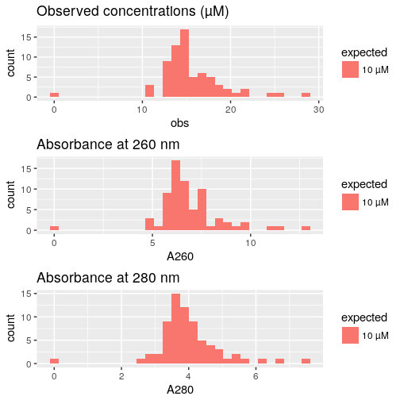

```r
hist_obs  <- ggplot(conc, aes(obs,  fill = expected)) +
  geom_histogram(bins=30) + ggtitle("Observed concentrations (µM)")
hist_a260 <- ggplot(conc, aes(A260, fill = expected)) +
  geom_histogram(bins=30) + ggtitle("Absorbance at 260 nm")
hist_a280 <- ggplot(conc, aes(A280, fill = expected)) +
  geom_histogram(bins=30) + ggtitle("Absorbance at 280 nm")

ggpubr::ggarrange(ncol = 1, nrow = 3, hist_obs, hist_a260, hist_a280)
```

# A260 vs A280

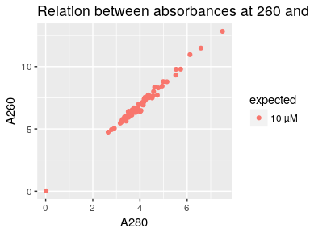

```r
ggplot(conc, aes(A280, A260, colour = expected)) + geom_point() +
  ggtitle("Relation between absorbances at 260 and 280 nm")
```

# Comparison between source and stock

The source plate was prepared with correction of the concentrations of the stock primers (see TSO_concentration_check2 for details).

Still, the observed molarity (15.5 µM ± 3.8) is significantly different from the expectation (10 µM).

```r
t.test(conc$obs, mu=10)
```

```
##
##  One Sample t-test
##
## data:  conc$obs
## t = 12.086, df = 69, p-value < 2.2e-16
## alternative hypothesis: true mean is not equal to 10
## 95 percent confidence interval:
##  14.58165 16.39315
## sample estimates:
## mean of x
##   15.4874
```

To see the effectiveness of the correction, we plot the observed dilution factors against the expected ones.

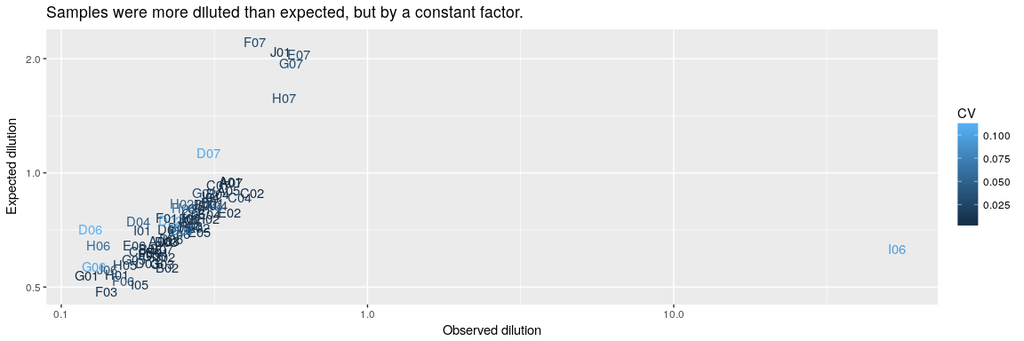

```r
stock <-
  read.table( "dilution_table.txt"
            , sep = "\t"
            , header = TRUE)[conc$ID, ]
conc$dil_exp <- stock$dilution_factor_for_100uM / 10
conc$dil_obs <- stock$source_obs_molarity / 200 / conc$obs

ggplot(conc, aes(dil_obs, dil_exp, colour = CV)) +
  geom_text(aes(label=Well)) +
  scale_x_log10("Observed dilution") +
  scale_y_log10("Expected dilution", breaks = c(0.5, 1, 2)) +
  ggtitle("Samples were more diluted than expected, but by a constant factor.")
```

The measurements with the highest noise (coefficient of variation, CV) are plotted in lighter tones of blue.